# Sensitivity analysis Oxygen Isotopes in cellulose

##### COURSE: DISC, LTRR, UNIVERSITY OF ARIZONA. INSTRUCTORS: P. SZEJNER & S. BELMECHERI

### Instructions:

The following activities should further your experience understanding the mechanistic drivers (parameters, variable) of 18O variability in tree rings. This exercise consists of a sensitivity analysis to investigate how different environmental factors and parameters affect the variability of 18O isotopes in the cellulose. The following calculations, like Notebook 2, are based on the Craig Gordon and the Roden models.

You will need to download or clone the R project from https://github.com/paulszejner/DISCO-Notebook4.git then, each of you will be able to set your working directory to proceed with this exercises. Once you open the `Notebook 4.Rproj` you can open the `Notebook 4.Rmd` file to proceed with the activity.

In the following, you will model the oxygen isotopes in cellulose `d18O_cellulose`. However, this exercise is intended for you to evaluate the sensitivity of the different variables. Namely, how cellulose 18O will vary if we vary the relative humidity `relH`, the source water `water`, the stomatal conductance`gs` and the percentage of exchange during the cellulose synthesis`F_0`

## PART 1: Variables

- First, create a vector [`relH` ] of relative humidity ranging from 10% to 90%.
- Second, create a vector [`water`] of Source water ranging from -25 to 5 permill.
- Third, create a 2 column object [`RH_SOURCE`] combining `relH` and `water` that correspond to all possible combinations of relative humidity and source water 18O.

```r
relH <- seq(10, 90, by=5) # this is the vector of 17 different Relative humidities
water <-seq( -25, 5,by = 2) # this is the vector with  16 source water isotopic values.

RH_SOURCE <- merge(relH, water) # here we merge the two variables to facilitate the calculations for each row of this object.

#Subset source  RH and source water 18O combinations:

RH <- RH_SOURCE[,1]
Source_18O <- RH_SOURCE[,2]
```

Plot RH and Source water 18O in order to visualize all the possible RH-Source water 18O combinations.  
Example: for RH= 20% there are 16 Source water 18O values ranging from -25 to 5 permill.

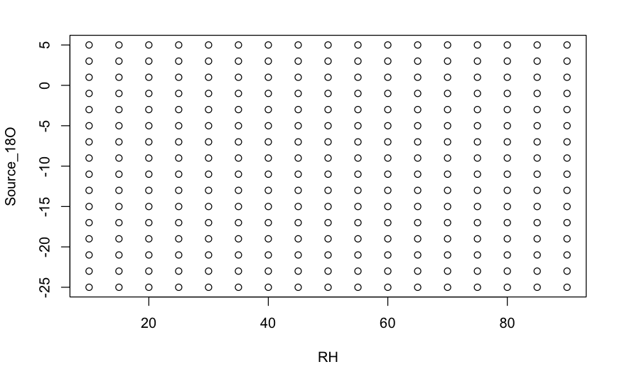

```r
plot(RH, Source_18O)
```

These RH-Source water combinations will be used as input for tree ring cellulose model. In addition, other variables such as stomatal conductance `gs` and percentage of isotope exchange during cellulose synthesis `F_0` will also be varied.

## PART 2: Modeling the Oxygen Isotopes in the tree ring cellulose

The leaf water enrichment and cellulose 18O will be predicted using a wide range of variability of two environmental variables (source water, RH) and two model parameters (gs and F_0).

### Varying Relative Humidity (RH) and Source water d18O:

The first part of the model will be run with a combination of RH and source water 18O as follows:

```r
# Constants
br <-1 # boundary layer conductance. (mol m-2 s-1), considered reasonable value between 0.02 to 3 in Roden paper boundary layer resistance.
ak <- 1.0285    #  Fractionation factor the liquid–vapor equilibrium fractionation factor and varies with temperature according to the equations of Majoube (1971).
akb <- 1.0189   #  Fractionation factor associated with diffusion in the boundary layer.
Stomatal_conductance <- 0.5 # stomatal conductance to water vapor.
# NOTE: stomatal conductance can be fixed or varies with respect to VPD.
press_bar <- 77 # barometric    pressure  (mmbar)
Ta <- 25 # In this exercise, we are using a constant temperature, air temp. (°C) with the assumption that Tleaf= Tair
rsmow <- 0.0020052 # Isotope ratio  form  Standard SMOW (Standard  mean ocean water)
```

First, we estimate the the isotopic value of the water vapor:

```r
water_vapor <-Source_18O +(-1*(1.137*(1000000/((Ta+273.15)^2))-0.4156*((1000/(Ta+273.15))-2.0667)))
```

Second, we estimate the vapor pressure e<sub>i</sub> in intercellular air space (Kpa) as follows:

```r
# ei is the saturation vapor pressure (kPa) with air temp, in this case at 25
ei=(101325*exp((((-0.1299*(1-(373.16/(273.15 + Ta)))-0.6445)*
                   (1-(373.16/(273.15 + Ta)))-1.976)*(1-(373.16/(273.15 + Ta)))+13.3185)*(1-(373.16/(273.15 + Ta)))))/1000
```

Third, we estimate the vapor pressure e<sub>a</sub> in bulk air (Kpa) as follows:

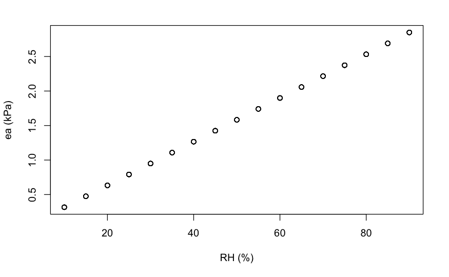

```r
# ea is the ambient vapor pressure (kPa)
ea =(RH/100)*ei

plot(RH,ea, xlab = "RH (%)",ylab = "ea (kPa)" )
```

## Question 1: Describe the relationship between the Relative humidity (RH) and the ambient vapor pressure (e<sub>a</sub>):

### Varying stomatal conductance:

In this next part of the model, the stomatal conductance (gs) will be varied using 3 values from 0.01-0.5:

```r
gs <- c(0.01,0.25, 0.5)

# The total conductance includes stomatal conductance to water vapor and boundary layer conductance:
g = 1/(1/gs + 1/br) # or 1/(rs+rb)

# E leaf transpiration (mol m-2 s-1) # Barbour 2004
# This list contains 3 different combinations of gs for many RH and Source water combination.
E <- list()
# This for loop will calculate the leaf transpiration E  which is the  conductance  time the  pressure gradient (fick´s law https://en.wikipedia.org/wiki/Fick%27s_laws_of_diffusion)

for (i in 1:3){E[[i]]=((ei-ea)/press_bar)*g[i] }
```

Check the structure of this new object E based n 3 stomatal conductance values: the former loop generated a list of 3 vectors of E

```r
str(E)
```

```
List of 3
 $ : num [1:272] 0.000366 0.000346 0.000326 0.000305 0.000285 ...
 $ : num [1:272] 0.0074 0.00699 0.00658 0.00617 0.00576 ...
 $ : num [1:272] 0.01233 0.01165 0.01096 0.01028 0.00959 ...
```

Plot the relationship between the Relative humidity (RH) and leaf transpiration (E):

```r
plot(RH,E[[1]],type="l", xlim = c(10,90), range(E), ylab="E (mol m-2 s-1)", xlab="RH (%)")
lines(RH,E[[2]], lwd=3)
```

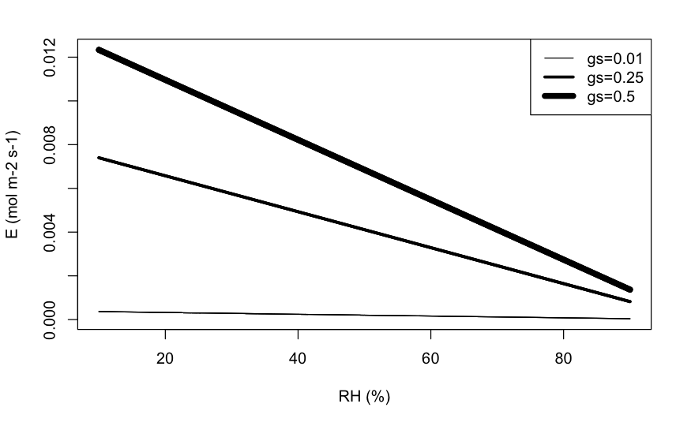

```r
lines(RH,E[[3]], lwd=6)
legend("topright", legend = c("gs=0.01","gs=0.25","gs=0.5" ), lwd = c(1,3,6))
```

## Question 2: Describe the relationship between RH and E under three different stomatal conductance values. How do the slopes differ and why you think this is happening?

Calculate the leaf water enrichment:

```r
# Convert  vapor pressures to mole fraction as follows:
wi=ei/press_bar
wa= ea/press_bar

# Calculate leaf surface water vapor (ws) mole fraction:
# this list contains 3 different combinations of gs for many RH and Source waters.
ws <- list()
for(i in 1:3){ws[[i]] =((gs[[i]]*wi)-E[[i]]*(1-wi/2))/(gs[[i]] - E[[i]]/2)}

# Calculate vapor pressure at leaf surface (es)
es<- list()
for(i in 1:3){es[[i]]=ws[[i]]*press_bar}

# Calculate the temperature dependent equilibrium fractionation factor alpha* (recall the phase change fractionation)
alpha_star =exp((1.137*1000/(273.15+Ta)^2)-(0.4156/(273.15+Ta))-0.0020667)

# Convert Source water 18O to R notation  (the inverse of delta notation)
Rsource= rsmow*(1+Source_18O/1000)

# Convert water vapor 18O to R notation
Ratm= rsmow*(1+water_vapor/1000)
```

Now, estimate R leaf for all combinations of RH, Source water 18O and gs: this again will generate a list of 3 with vectors of 272 values that include all combinations of RH and source.

```r
Rleaf<- list()

for(i in 1:3){
  Rleaf[[i]] <- alpha_star*((ak*Rsource*((ei-es[[i]])/ei))+
                              (akb*Rsource*((es[[i]]-ea)/ei))+
                              (Ratm*(ea/ei)))
}
```

Convert leaf water enrichment to permill (delta notation ) values as follows:

```r
d18Oleaf <- list()

for(i in 1:3){
  d18Oleaf[[i]]=((Rleaf[[i]]/rsmow)-1)*1000
}
```

Plot leaf water enrichment with varying source water 18O:

```r
# Example: [1:17] is all RHs and  with the same source water of -25 permill
plot(RH[1:17],  d18Oleaf [[1]][1:17], type="l", ylim = c(-30,10))
lines(RH[1:17], d18Oleaf [[2]][1:17], lwd=3)
```

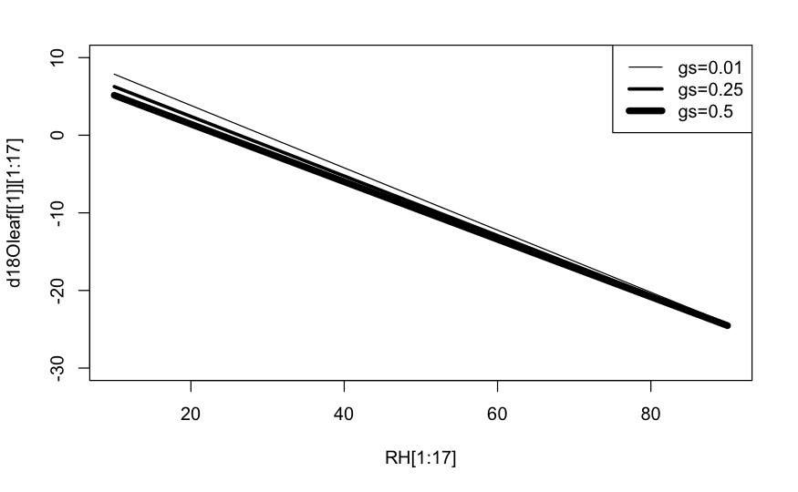

```r
lines(RH[1:17], d18Oleaf [[3]][1:17], lwd=6)

legend("topright", legend = c("gs=0.01","gs=0.25","gs=0.5" ), lwd = c(1,3,6))
```

## Question 3: Describe how leaf water enrichment depend on RH. Does this relationship (slope) vary depending on gs values?

Now lets plot delta 18O and gs on the situations under low and high relative humidity

```r
low_rh <- c(d18Oleaf[[1]][1],d18Oleaf[[2]][1],d18Oleaf[[3]][1]) #leaf enrichment  unde low rh
high_rh <- c(d18Oleaf[[1]][17],d18Oleaf[[2]][17],d18Oleaf[[3]][17])#leaf enrichment  unde high rh
mean_rh <- c(d18Oleaf[[1]][8],d18Oleaf[[2]][8],d18Oleaf[[3]][8])#leaf enrichment  unde high rh

plot(low_rh, gs, type = "l", lwd=1, xlab ="leaf water enrichment d18O_leaf", ylim = range(gs), xlim = range(c(low_rh, high_rh)))
lines(mean_rh, gs, lwd=3)
```

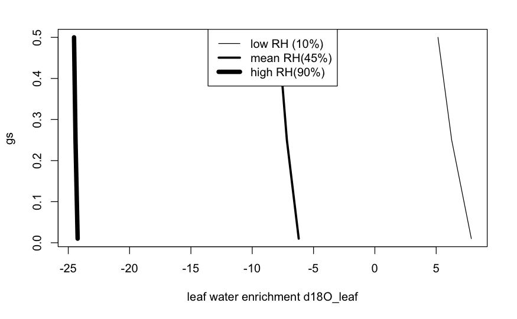

```r
lines(high_rh, gs, lwd=6)
legend("top", legend = c("low RH (10%)","mean RH(45%)", "high RH(90%)" ), lwd = c(1,3,6))
```

```r
NA
NA
```

#### Varying the proportion of exchanges with local water F_0:

The proportion (F_0) of carbohydrate d18O signal from leaf carbohydrate that exchanges with local water during formation of tree-ring or leaf cellulose will be varied to estimate cellulose d18O as follows:

```r
F_0 <- c(0.33,0.42,0.55) # variable percentage of Exchange during Cellulose Synthesis F_0  or PEX
epsilon_o <-  27 # Biological fractionation factor for oxygen in going from sugars to cellulose
# here a double loop

d18O_cellulose <- list()
for(i in 1:3){
  d18Oc_F_0 <- list()
  for (z in 1:3){ # variable percentage of Exchange during Cellulose Synthesis
    d18Oc_F_0[[z]] <- F_0[[z]]*(Source_18O + epsilon_o) + (1 - F_0[[z]]) * (d18Oleaf[[i]]+ epsilon_o)
  }
  names(d18Oc_F_0) <- c("gs=0.01","gs=0.25","gs=0.5" )
d18O_cellulose[[i]] <- d18Oc_F_0
}
names(d18O_cellulose) <- c("fo=0.33","fo=0.42","fo=0.55" )
```

```r
str(d18O_cellulose)
```

```
List of 3
 $ fo=0.33:List of 3
  ..$ gs=0.01: num [1:272] 24 22.7 21.3 20 18.6 ...
  ..$ gs=0.25: num [1:272] 21.1 19.9 18.7 17.6 16.4 ...
  ..$ gs=0.5 : num [1:272] 16.8 15.9 15 14.1 13.2 ...
 $ fo=0.42:List of 3
  ..$ gs=0.01: num [1:272] 22.9 21.7 20.4 19.1 17.8 ...
  ..$ gs=0.25: num [1:272] 20.1 19 17.9 16.8 15.7 ...
  ..$ gs=0.5 : num [1:272] 16.1 15.2 14.3 13.5 12.6 ...
 $ fo=0.55:List of 3
  ..$ gs=0.01: num [1:272] 22.2 21 19.7 18.5 17.2 ...
  ..$ gs=0.25: num [1:272] 19.5 18.4 17.3 16.3 15.2 ...
  ..$ gs=0.5 : num [1:272] 15.6 14.7 13.9 13.1 12.2 ...
```

Each vector of the list corresponds to the suite of combinations we had at the start of this exercise where `RH_SOURCE` is the main structure for all 17 different Relative humidity values `RH`and the 16 different source waters d18O `water` which provides 272 values for each vector from the list.

## PART 3: Estimate the slope between diferent variables and the Isotopic effect estimated in cellulose

This final step will estimate the different sensitivities the `d18O_cellulose` is exposed under different environments and different factors. Then, you will need to conclude what factors analyzed in this exercise are the most sensitive and why.

The following plot is a ¨simple¨ example of how to use the dataset we just generated so we can extract/use any data you chose. In this example, we will select a subset of the data using two different isotopic sources of water `water` , one subset with -25 and the other using a source of -5 and will plot the relationship between `RH` and the `d18O_cellulose`.

```r
## set the fraction of the vector we liket to plot
source1 <- RH_SOURCE[,2]==-25 # in this case we select the  positions  that  have a sorce water of -25
source2 <- RH_SOURCE[,2]==-5# in this case we select the  positions  that  have a sorce water of -5


plot(RH_SOURCE[,1][source2],d18O_cellulose[["fo=0.55"]][["gs=0.01"]][source2], xlim =range(RH_SOURCE[,1]), ylim =range(unlist(d18O_cellulose)),  pch=19, xlab = "RH", ylab = "d18O")

  points(RH_SOURCE[,1][source2],d18O_cellulose[["fo=0.55"]][["gs=0.25"]][source2], pch=2)
```

```r
  points(RH_SOURCE[,1][source2],d18O_cellulose[["fo=0.55"]][["gs=0.5"]][source2])

  points(RH_SOURCE[,1][source2],d18O_cellulose[["fo=0.33"]][["gs=0.01"]][source2],  pch=19, col="red" )
```

```r
  points(RH_SOURCE[,1][source2],d18O_cellulose[["fo=0.33"]][["gs=0.25"]][source2], pch=2, col="red" )
  points(RH_SOURCE[,1][source2],d18O_cellulose[["fo=0.33"]][["gs=0.5"]][source2], col="red" )
```

```r
  points(RH_SOURCE[,1][source2],d18O_cellulose[["fo=0.42"]][["gs=0.01"]][source2],  pch=19, col="blue" )
  points(RH_SOURCE[,1][source2],d18O_cellulose[["fo=0.42"]][["gs=0.25"]][source2], pch=2, col="blue" )
```

```r
  points(RH_SOURCE[,1][source2],d18O_cellulose[["fo=0.42"]][["gs=0.5"]][source2], col="blue" )

  points(RH_SOURCE[,1][source1],d18O_cellulose[["fo=0.55"]][["gs=0.01"]][source1],  pch=19, col="red" )
```

```r
  points(RH_SOURCE[,1][source1],d18O_cellulose[["fo=0.55"]][["gs=0.25"]][source1], pch=2)
  points(RH_SOURCE[,1][source1],d18O_cellulose[["fo=0.55"]][["gs=0.5"]][source1])
```

```r
  points(RH_SOURCE[,1][source1],d18O_cellulose[["fo=0.33"]][["gs=0.01"]][source1],  pch=19, col="red" )
  points(RH_SOURCE[,1][source1],d18O_cellulose[["fo=0.33"]][["gs=0.25"]][source1], pch=2, col="red" )
```

```r
  points(RH_SOURCE[,1][source1],d18O_cellulose[["fo=0.33"]][["gs=0.5"]][source1], col="red" )

  points(RH_SOURCE[,1][source1],d18O_cellulose[["fo=0.42"]][["gs=0.01"]][source1],  pch=19, col="blue" )
```

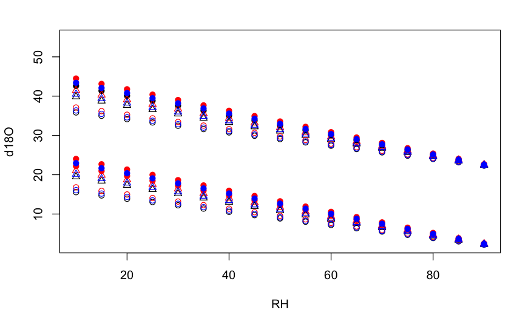

```r
  points(RH_SOURCE[,1][source1],d18O_cellulose[["fo=0.42"]][["gs=0.25"]][source1], pch=2, col="blue" )
  points(RH_SOURCE[,1][source1],d18O_cellulose[["fo=0.42"]][["gs=0.5"]][source1], col="blue" )
```

The following plot is a ¨simple¨ example of how to use the dataset we just generated so we can extract/use any data you chose. Now, in this example, we will select a subset of the data using two different relative humidities`RH`, one subset with on 10%. The other using 90% and will plot the relationship between the isotopic ratio of the source water `water` and the recorded/modeled `d18O_cellulose`.

```r
RH1 <- RH_SOURCE[,1]== 10 # in this case we select the  positions using a 10%
RH2 <- RH_SOURCE[,1]==90# in this case we select the  positions using a 90%


plot(RH_SOURCE[,2][RH2],d18O_cellulose[["fo=0.55"]][["gs=0.01"]][RH2], xlim =range(RH_SOURCE[,2]), ylim =range(unlist(d18O_cellulose)),  pch=19, xlab = "Source water", ylab = "d18O")
  points(RH_SOURCE[,2][RH2],d18O_cellulose[["fo=0.55"]][["gs=0.25"]][RH2], pch=2)
```

```r
  points(RH_SOURCE[,2][RH2],d18O_cellulose[["fo=0.55"]][["gs=0.5"]][RH2])


  points(RH_SOURCE[,2][RH2],d18O_cellulose[["fo=0.33"]][["gs=0.01"]][RH2],  pch=19, col="red" )
```

```r
  points(RH_SOURCE[,2][RH2],d18O_cellulose[["fo=0.33"]][["gs=0.25"]][RH2], pch=2, col="red" )
  points(RH_SOURCE[,2][RH2],d18O_cellulose[["fo=0.33"]][["gs=0.5"]][RH2], col="red" )
```

```r
  points(RH_SOURCE[,2][RH2],d18O_cellulose[["fo=0.42"]][["gs=0.01"]][RH2],  pch=19, col="blue" )
  points(RH_SOURCE[,2][RH2],d18O_cellulose[["fo=0.42"]][["gs=0.25"]][RH2], pch=2, col="blue" )
```

```r
  points(RH_SOURCE[,2][RH2],d18O_cellulose[["fo=0.42"]][["gs=0.5"]][RH2], col="blue" )


  points(RH_SOURCE[,2][RH1],d18O_cellulose[["fo=0.55"]][["gs=0.01"]][RH1],  pch=19, col="red" )
```

```r
  points(RH_SOURCE[,2][RH1],d18O_cellulose[["fo=0.55"]][["gs=0.25"]][RH1], pch=2)
  points(RH_SOURCE[,2][RH1],d18O_cellulose[["fo=0.55"]][["gs=0.5"]][RH1])
```

```r
  points(RH_SOURCE[,2][RH1],d18O_cellulose[["fo=0.33"]][["gs=0.01"]][RH1],  pch=19, col="red" )
  points(RH_SOURCE[,2][RH1],d18O_cellulose[["fo=0.33"]][["gs=0.25"]][RH1], pch=2, col="red" )
```

```r
  points(RH_SOURCE[,2][RH1],d18O_cellulose[["fo=0.33"]][["gs=0.5"]][RH1], col="red" )

  points(RH_SOURCE[,2][RH1],d18O_cellulose[["fo=0.42"]][["gs=0.01"]][RH1],  pch=19, col="blue" )
```

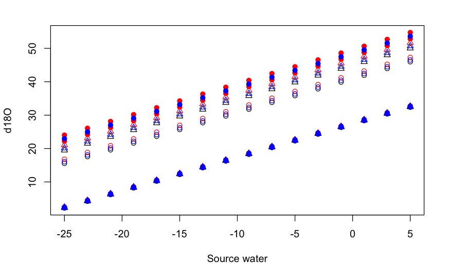

```r
  points(RH_SOURCE[,2][RH1],d18O_cellulose[["fo=0.42"]][["gs=0.25"]][RH1], pch=2, col="blue" )
  points(RH_SOURCE[,2][RH1],d18O_cellulose[["fo=0.42"]][["gs=0.5"]][RH1], col="blue" )
```

In this final step, we will plot all in one figure panel with all the values estimated. For example, the following plot is a three-by-three panel using heat maps of the RH, Source vectors with the variable colors showing the isotopic ratio of cellulose.

However, first, we should arrange the data on nine matrices containing all possible variations that we have modeled.

```r
#generation of the 9 matrices with 17 different Realtive by 16 different waters

d18O__fo0.55_gs0.01 <- matrix (d18O_cellulose[["fo=0.55"]][["gs=0.01"]], nrow = 17, ncol = 16, byrow = F, dimnames = list(as.character(relH),as.character(water)))
d18O__fo0.55_gs0.25 <- matrix (d18O_cellulose[["fo=0.55"]][["gs=0.25"]], nrow = 17, ncol = 16, byrow = F, dimnames = list(as.character(relH),as.character(water)))
d18O__fo0.55_gs0.5 <- matrix (d18O_cellulose[["fo=0.55"]][["gs=0.5"]], nrow = 17, ncol = 16, byrow = F, dimnames = list(as.character(relH),as.character(water)))

d18O__fo0.33_gs0.01 <- matrix (d18O_cellulose[["fo=0.33"]][["gs=0.01"]], nrow = 17, ncol = 16, byrow = F, dimnames = list(as.character(relH),as.character(water)))
d18O__fo0.33_gs0.25 <- matrix (d18O_cellulose[["fo=0.33"]][["gs=0.25"]], nrow = 17, ncol = 16, byrow = F, dimnames = list(as.character(relH),as.character(water)))
d18O__fo0.33_gs0.5 <- matrix (d18O_cellulose[["fo=0.33"]][["gs=0.5"]], nrow = 17, ncol = 16, byrow = F, dimnames = list(as.character(relH),as.character(water)))

d18O__fo0.42_gs0.01 <-matrix ( d18O_cellulose[["fo=0.42"]][["gs=0.01"]], nrow = 17, ncol = 16, byrow = F, dimnames = list(as.character(relH),as.character(water)))
d18O__fo0.42_gs0.25 <- matrix (d18O_cellulose[["fo=0.42"]][["gs=0.25"]], nrow = 17, ncol = 16, byrow = F, dimnames = list(as.character(relH),as.character(water)))
d18O__fo0.42_gs0.5 <- matrix (d18O_cellulose[["fo=0.42"]][["gs=0.5"]], nrow = 17, ncol = 16, byrow = F, dimnames = list(as.character(relH),as.character(water)))

COLIS <- colorRampPalette(colors = c("red", "blue", "black"))
```

```r
col_panel <- COLIS(10)
range_limits <- range(unlist(d18O_cellulose))

layout(mat = matrix(c(1:9,10,10,10),nrow = 4, ncol = 3, byrow = T), widths = c(1.4,1.4,1.4), heights = c(1,1,1,1), respect = T)
par(mar=c(4,4,0.2,0))

image(x = water, y = relH, z = t(d18O__fo0.33_gs0.01),col = col_panel, zlim = c(0,60))
image(x = water, y = relH, z = t(d18O__fo0.33_gs0.25),col = col_panel, zlim = c(0,60))
```

```r
image(x = water, y = relH, z = t(d18O__fo0.33_gs0.5),col = col_panel, zlim = c(0,60))
image(x = water, y = relH, z = t(d18O__fo0.42_gs0.01),col = col_panel, zlim = c(0,60))
```

```r
image(x = water, y = relH, z = t(d18O__fo0.42_gs0.25),col = col_panel, zlim = c(0,60))
image(x = water, y = relH, z = t(d18O__fo0.42_gs0.5),col = col_panel, zlim = c(0,60))
```

```r
image(x = water, y = relH, z = t(d18O__fo0.55_gs0.01),col = col_panel, zlim = c(0,60))
image(x = water, y = relH, z = t(d18O__fo0.55_gs0.25),col = col_panel, zlim = c(0,60))
```

```r
image(x = water, y = relH, z = t(d18O__fo0.55_gs0.5),col = col_panel, zlim = c(0,60))

## over comlicated way to plot a color bar///
source("col_bar.R")
par(mar=c(4,4,3,0))
```

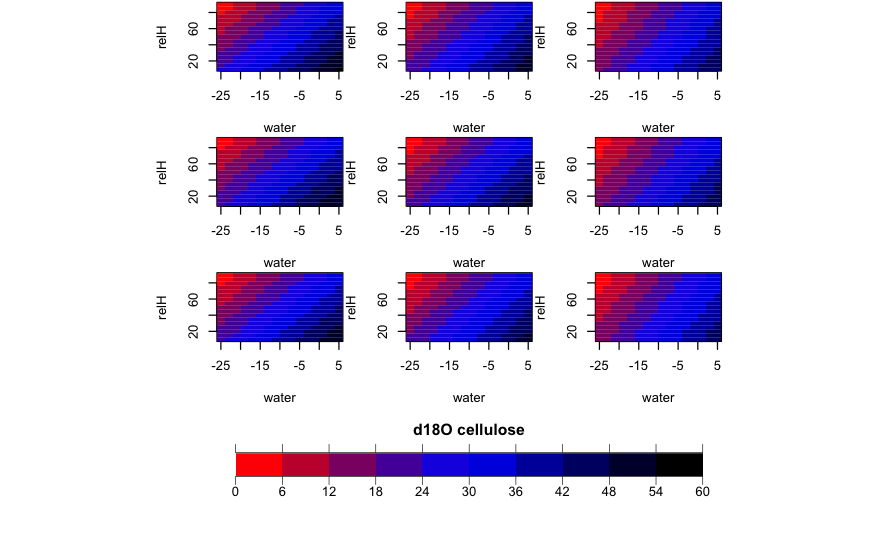

```r
color.bar_h(col_panel, min = 0, max = 60, nticks = 11, title = "d18O cellulose")
```

### Exercise

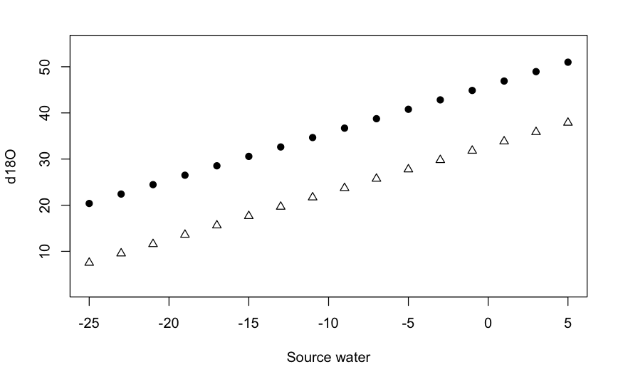

```r
#hint. Imagine a  box that covers the rage given. Then you can precisely estimate the potential rage in d18O by using the slopes between the variables and d18O in cellulose and calculate the range of variation between the given range of environmental conditions.

RH1 <- RH_SOURCE[,1]== 20 # in this case we select the  positions using a 20%
RH2 <- RH_SOURCE[,1]==70# in this case we select the  positions using a 70%

source1 <- RH_SOURCE[,2]==-9 # in this case we select the  positions  that  have a sorce water of -9
source2 <- RH_SOURCE[,2]==-5# in this case we select the  positions  that  have a sorce water of -5

plot(RH_SOURCE[,2][RH1],d18O_cellulose[["fo=0.42"]][["gs=0.01"]][RH1], xlim =range(RH_SOURCE[,2]), ylim =range(unlist(d18O_cellulose)),  pch=19, xlab = "Source water", ylab = "d18O")
  points(RH_SOURCE[,2][RH2],d18O_cellulose[["fo=0.42"]][["gs=0.01"]][RH2], pch=2)
```

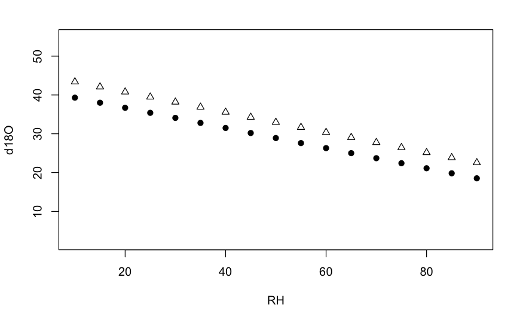

```r
plot(RH_SOURCE[,1][source1],d18O_cellulose[["fo=0.42"]][["gs=0.01"]][source1], xlim =range(RH_SOURCE[,1]), ylim =range(unlist(d18O_cellulose)),  pch=19, xlab = "RH", ylab = "d18O")
  points(RH_SOURCE[,1][source2],d18O_cellulose[["fo=0.42"]][["gs=0.01"]][source2], pch=2)
```

```r
RH1 <- RH_SOURCE[,1]== 80
RH2 <- RH_SOURCE[,1]==90

source1 <- RH_SOURCE[,2]==-13
source2 <- RH_SOURCE[,2]==-7

plot(RH_SOURCE[,2][RH1],d18O_cellulose[["fo=0.42"]][["gs=0.01"]][RH1], xlim =range(RH_SOURCE[,2]), ylim =range(unlist(d18O_cellulose)),  pch=19, xlab = "Source water", ylab = "d18O")
  points(RH_SOURCE[,2][RH2],d18O_cellulose[["fo=0.42"]][["gs=0.01"]][RH2], pch=2)

plot(RH_SOURCE[,1][source1],d18O_cellulose[["fo=0.42"]][["gs=0.01"]][source1], xlim =range(RH_SOURCE[,1]), ylim =range(unlist(d18O_cellulose)),  pch=19, xlab = "RH", ylab = "d18O")
  points(RH_SOURCE[,1][source2],d18O_cellulose[["fo=0.42"]][["gs=0.01"]][source2], pch=2)
```

[output not shown]

Question 4: what is the most important variable in each of the cases? Can you say how much the source influences the cellulose and how much the relative humidity affects the outcome in d18O in cellulose?

Question 5: is there a significant difference between the d18O in cellulose when gs varies from 0.01 to 0.5?